# Previsione di opportunità di Cross Sell di assicurazioni

Il cliente è una compagnia di assicurazioni che ha fornito un'assicurazione sanitaria ai suoi clienti, adesso hanno bisogno del tuo aiuto per costruire un modello predittivo in grado di prevedere se gli assicurati dell'anno passato potrebbero essere interessati ad acquistare anche un'assicurazione per il proprio veicolo.

Il dataset è composto dalle seguenti proprietà:

- **id**: id univoco dell'acquirente.
- **Gender**: sesso dell'acquirente.
- **Age**: età dell'acquirente.
- **Driving_License**: 1 se l'utente ha la patente di guida, 0 altrimenti.
- **Region_Code**: codice univoco della regione dell'acquirente.
- **Previously_Insured**: 1 se l'utente ha già un veicolo assicurato, 0 altrimenti.
- **Vehicle_Age**: età del veicolo
- **Vehicle_Damage**: 1 se l'utente ha danneggiato il veicolo in passato, 0 altrimenti.
- **Annual_Premium**: la cifra che l'utente deve pagare come premio durante l'anno.
- **Policy_Sales_Channel**: codice anonimizzato del canale utilizzato per la proposta (es. per email, per telefono, di persona, ecc...)
- **Vintage**: numero di giorni dalla quale l'utente è cliente dell'azienda.
- **Response**: 1 se l'acquirente ha risposto positivametne alla proposta di vendità, 0 altrimenti.

L'obiettivo del modello è prevedere il valore di **Response**.

```python
import pandas as pd
import matplotlib.pyplot as plt
import seaborn as sns
import numpy as np

from sklearn.preprocessing import LabelEncoder, OrdinalEncoder, OneHotEncoder, StandardScaler
from sklearn.compose import ColumnTransformer
from sklearn.pipeline import Pipeline
from sklearn.linear_model import LogisticRegression
from sklearn.model_selection import train_test_split, StratifiedKFold, cross_val_score, cross_validate
from sklearn.metrics import classification_report, confusion_matrix, precision_score, recall_score, f1_score, accuracy_score, RocCurveDisplay, roc_curve, auc, roc_auc_score
from imblearn.over_sampling import SMOTE
from imblearn.pipeline import Pipeline as ImbPipeline
```

```python
# per non visualizzare i warnings:
import warnings
warnings.filterwarnings("ignore", category=UserWarning)

# NOTA. I punti del codice dove potrebbero verificarsi dei warnings sono commentati.
```

```python
# Importazione del dataset
df = pd.read_csv("insurance_cross_sell.csv")
df.head()
```

|  | id | Gender | Age | Driving_License | Region_Code | Previously_Insured | Vehicle_Age | Vehicle_Damage | Annual_Premium | Policy_Sales_Channel | Vintage | Response |
| --- | --- | --- | --- | --- | --- | --- | --- | --- | --- | --- | --- | --- |
| 0 | 1 | Male | 44 | 1 | 28.0 | 0 | > 2 Years | Yes | 40454.0 | 26.0 | 217 | 1 |
| 1 | 2 | Male | 76 | 1 | 3.0 | 0 | 1-2 Year | No | 33536.0 | 26.0 | 183 | 0 |
| 2 | 3 | Male | 47 | 1 | 28.0 | 0 | > 2 Years | Yes | 38294.0 | 26.0 | 27 | 1 |
| 3 | 4 | Male | 21 | 1 | 11.0 | 1 | < 1 Year | No | 28619.0 | 152.0 | 203 | 0 |
| 4 | 5 | Female | 29 | 1 | 41.0 | 1 | < 1 Year | No | 27496.0 | 152.0 | 39 | 0 |

```python
# Verifica che non ci siano dati mancanti
df.isna().sum()
```

```
id                      0
Gender                  0
Age                     0
Driving_License         0
Region_Code             0
Previously_Insured      0
Vehicle_Age             0
Vehicle_Damage          0
Annual_Premium          0
Policy_Sales_Channel    0
Vintage                 0
Response                0
dtype: int64
```

```python
# Verifica che non ci siano valori infiniti (positivi o negativi) nel dataframe
df.isin([np.inf, -np.inf]).sum()
```

```
id                      0
Gender                  0
Age                     0
Driving_License         0
Region_Code             0
Previously_Insured      0
Vehicle_Age             0
Vehicle_Damage          0
Annual_Premium          0
Policy_Sales_Channel    0
Vintage                 0
Response                0
dtype: int64
```

# 1. Esplorazione del Dataset

L'esplorazione preliminare del dataset permetterà di comprendere meglio la distribuzione delle caratteristiche e delle variabili target. In particolare, si analizzeranno:

- La distribuzione della variabile "Response", per identificare eventuali sbilanciamenti tra clienti che accettano o rifiutano l'offerta di cross-sell.
- Le relazioni tra variabili chiave come Annual Premium, Vehicle Age, Previously Insured, e la risposta del cliente.

Valore aggiunto: Un'accurata esplorazione dei dati permette di identificare pattern nascosti e punti critici che influenzeranno il successo del modello predittivo.

## 1.1. Distribuzione della variabile 'Response'

1: corrisponde a un cliente che ha accettato la proposta di vendita

0: corrisponde a un cliente che ha rifiutato la proposta di vendita

```
Frequenze assolute
Response
0    334399
1     46710
Name: count, dtype: int64
Frequenze relative
Response
0    87.743664
1    12.256336
Name: proportion, dtype: float64
```

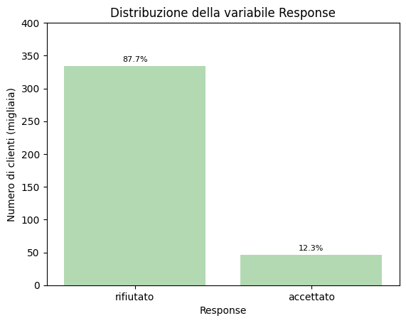

```python
# distribuzione di frequenze
print("Frequenze assolute")
fa = df['Response'].value_counts()
print(fa)
print("Frequenze relative")
fr = df['Response'].value_counts(normalize=True) * 100
print(fr)

# Grafico a barre
plot = sns.countplot(x='Response', data=df, color='#addfad')
plt.title('Distribuzione della variabile Response')
plt.xlabel('Response')
plt.ylabel('Numero di clienti (migliaia)')

# etichette asse x
plot.set_xticks([0, 1])
plot.set_xticklabels(['rifiutato', 'accettato'])

# etichette asse y
y_ticks = plot.get_yticks()
plot.set_yticks(y_ticks)
plot.set_yticklabels((y_ticks / 1000).astype(int))

# percentuali sopra le barre

total = len(df)

for p in plot.patches:
    height = p.get_height()
    plot.annotate(f"{height/total*100:.1f}%",
                  (p.get_x() + p.get_width() / 2., height),
                  ha='center',
                  va='bottom',
                  fontsize=8,
                  xytext=(0, 3),
                  textcoords='offset points')

plt.show()
```

La distribuzione della variabile target 'Response' risulta **fortemente sbilanciata**: la maggior parte dei clienti (87.7%) non accetta l’offerta di cross-sell.

### --> Gestione dello Sbilanciamento delle Classi

Gestire correttamente lo sbilanciamento delle classi è cruciale per evitare modelli che abbiano un alto tasso di falsi negativi, migliorando così la precisione del cross-sell.

Per affrontare questo problema, verranno successivamente utilizzate tecniche di:

- Class Weights: penalizzazione della classe più frequente nel modello. Questo impone un costo aggiuntivo al modello per errori di classificazione sulla classe di minoranza durante l'addestramento.
- Oversampling o Undersampling: creazione di un dataset più bilanciato per migliorare la capacità del modello di generalizzare.

## 1.2. Relazioni tra le variabili

```python
# Raggruppamento delle variabili per lo studio della relazione tra variabili
categorical_variables = ["Gender", "Driving_License", "Previously_Insured", "Vehicle_Age",
                         "Vehicle_Damage"]
categorical_variables_with_many_categories = ["Region_Code", "Policy_Sales_Channel"]
continuous_variables = ["Age", "Annual_Premium", "Vintage"]
```

```python
def plot_categorical_vs_response(var, top_n=None):
    """
    Barplot del tasso di risposta positiva al cross-sell per una variabile categorica.
    Mostra sopra le barre:
    - percentuale di risposta
    - numero totale osservazioni

    Args:
    - var: variabile categorica
    - top_n: se è specificato, mostra solo le prime N categorie per tasso di risposta.
    Serve a rendere interpretabile il barplot con molte categorie.
    Default = None
    """

    # calcolo statistiche
    grouped = df.groupby(var)['Response'].agg(['mean', 'count'])
    grouped = grouped.rename(columns={
        'mean': 'response_rate',
        'count': 'n_total'
    }).sort_values(by='response_rate', ascending=False)

    # selezione top N se richiesto
    if top_n:
        grouped = grouped.head(top_n)

    plt.figure(figsize=(max(8, len(grouped)*0.4), 6))
    ax = sns.barplot(x=grouped.index, y=grouped['response_rate'], color='#addfad')

    plt.title(f"{var} vs Response")
    plt.xlabel(var)
    plt.ylabel("Tasso di risposta positiva")
    plt.ylim(0, 1)
    plt.xticks(rotation=90, fontsize=8)

    # Annotazioni sopra le barre
    for i, p in enumerate(ax.patches):
        height = p.get_height()

       # 'Policy_Sales_Channel' --> viene mostrato anche il numero di esempi, e si usa un fontsize più piccolo
        if var == "Policy_Sales_Channel":
            n_total = grouped.iloc[i]['n_total']
            label = f"{height*100:.1f}%\n({int(n_total)})"
            fontsize = 6
        else:
            label = f"{height*100:.1f}%"
            fontsize = 7

        ax.annotate(
            label,
            (p.get_x() + p.get_width() / 2., height),
            ha='center',
            va='bottom',
            fontsize=fontsize,
            xytext=(0, 5),
            textcoords='offset points'
        )

    plt.tight_layout()
    plt.show()
```

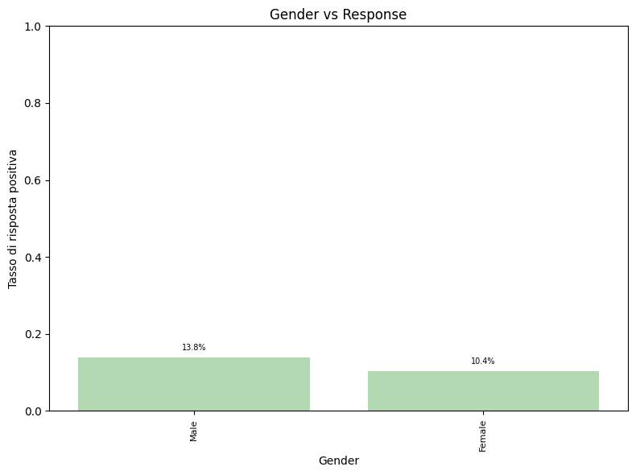

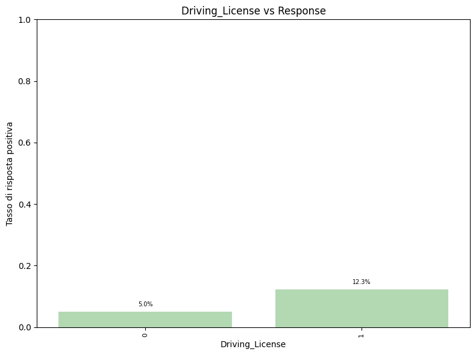

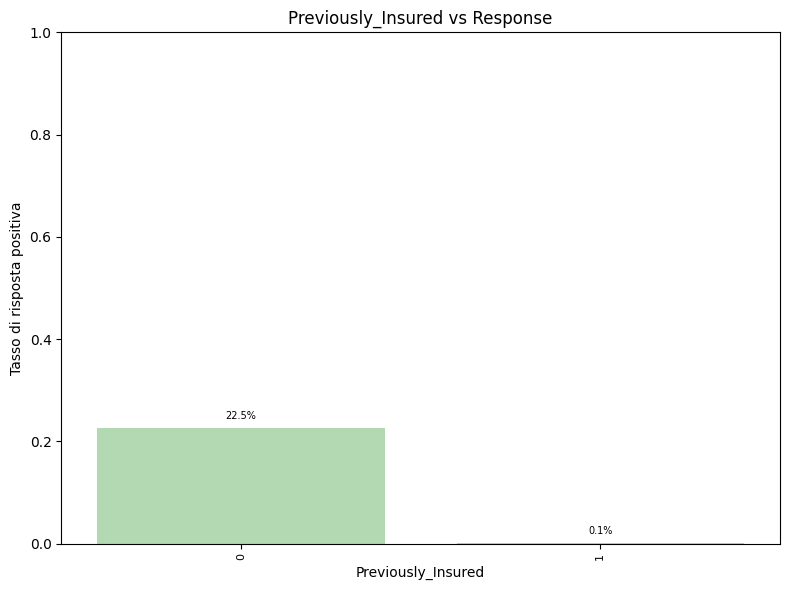

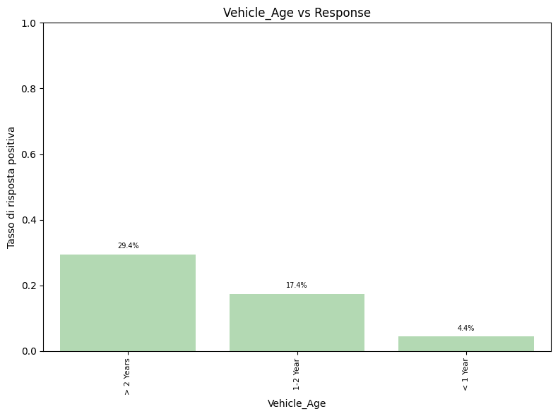

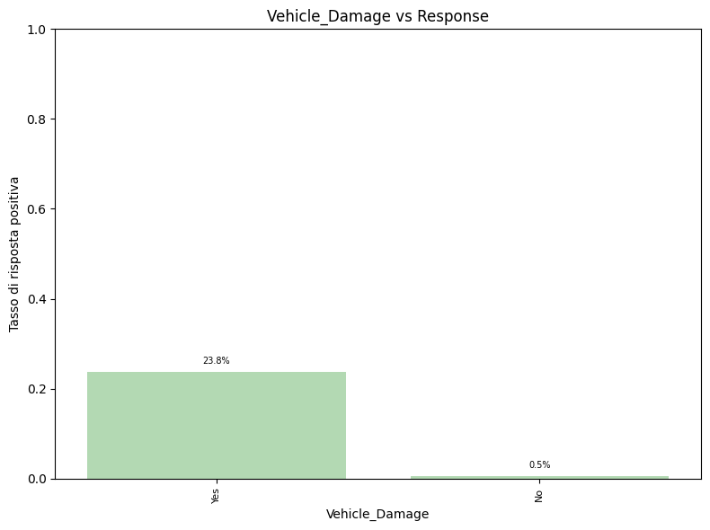

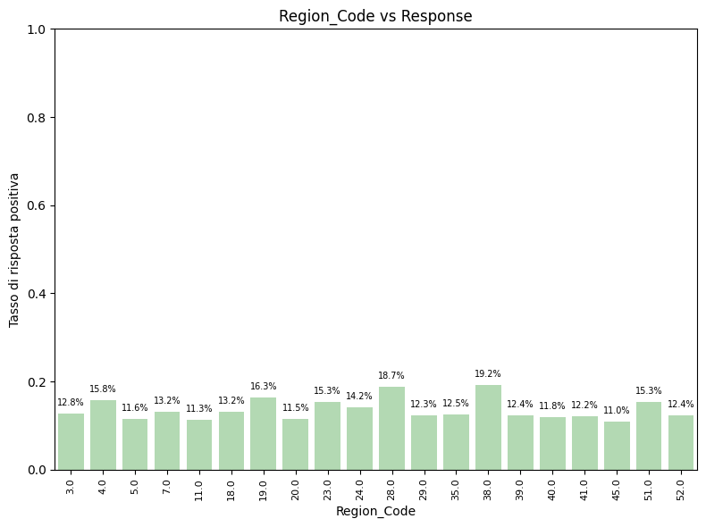

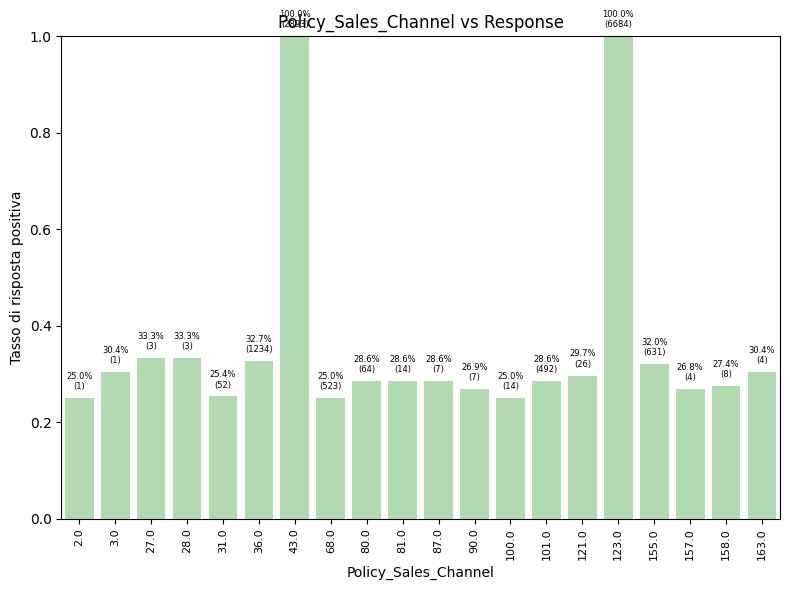

```python
for var in categorical_variables:
    plot_categorical_vs_response(var)

for var in categorical_variables_with_many_categories:
    plot_categorical_vs_response(var, top_n=20)
```

```python
# Funzione per analizzare la relazione tra ogni variabile continua e 'Response'

def plot_continuous_vs_response(var):
    """
    Boxplot + Violin plot di una variabile continua rispetto alla variabile target Response,
    con scala log per Annual_Premium e statistiche descrittive.

    Args:
    - var: variabile continua.
    """

    # divisione dello spazio grafico in 2
    fig, axes = plt.subplots(1, 2, figsize=(14, 5))

    # 1. BOXPLOT

    sns.boxplot(x='Response',
                y=var,
                data=df,
                color='#addfad',
                ax=axes[0],
                showfliers=False)

    axes[0].set_title(f"{var} vs Response (Boxplot)")
    axes[0].set_xlabel("Response")
    axes[0].set_ylabel(var)


    # Scala logaritmica solo per Annual_Premium
    if var.lower() == "annual_premium":
        axes[0].set_yscale("log")


    # 2. VIOLIN PLOT

    sns.violinplot(x="Response",
                   y=var,
                   data=df,
                   color='#addfad',
                   inner="quartile",
                   ax=axes[1])

    axes[1].set_title(f"{var} vs Response (Violin plot)")
    axes[1].set_xlabel("Response")
    axes[1].set_ylabel(var)

    # Scala logaritmica solo per Annual_Premium
    if var.lower() == "annual_premium":
        axes[1].set_yscale("log")


    # Mostra i grafici
    plt.tight_layout()
    plt.show()


    # 3. STATISTICHE NUMERICHE
    stats = (df.groupby("Response")[var]
             .agg(["mean", "median"])
             .rename(columns={"mean": "Mean", "median": "Median"}))

    # Mostra le statistiche
    display(stats)
```

NOTA. La variabile *Annual_premium* è fortemente asimmetrica e presenta diversi outlier, quindi è stata applicata una trasformazione logaritmica per ridurre asimmetria e outlier.

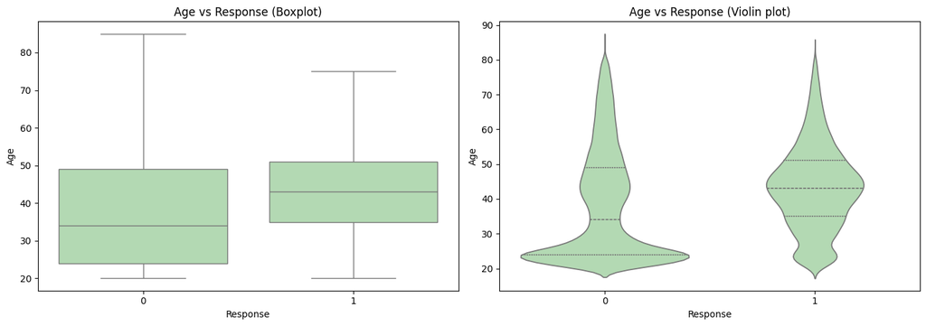

| Response | Mean | Median |
| --- | --- | --- |
| 0 | 38.178227 | 34.0 |
| 1 | 43.435560 | 43.0 |

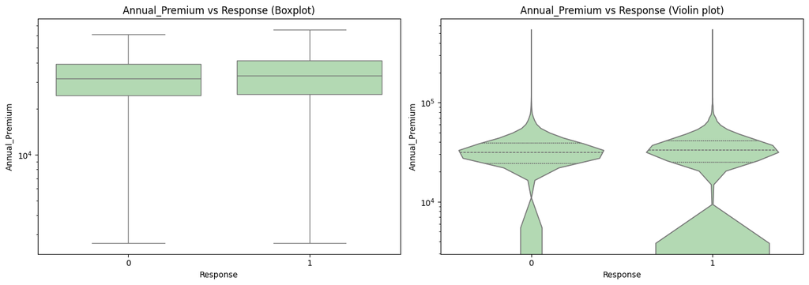

| Response | Mean | Median |
| --- | --- | --- |
| 0 | 30419.160276 | 31504.0 |
| 1 | 31604.092742 | 33002.0 |

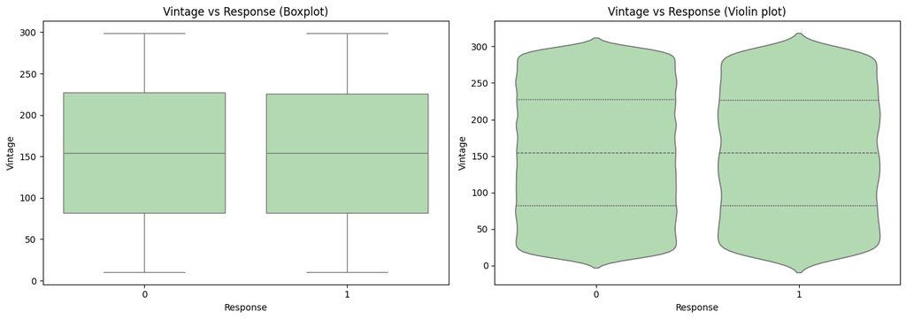

| Response | Mean | Median |
| --- | --- | --- |
| 0 | 154.380243 | 154.0 |
| 1 | 154.112246 | 154.0 |

```python
# Applica la funzione
for var in continuous_variables:
    plot_continuous_vs_response(var)
```

#### **Interpretazione dei risultati - variabili categoriche**

- **Gender vs Response**

I clienti maschi mostrano una propensione leggermente maggiore ad accettare l’offerta: 13.8% per i maschi e 10.4 per le femmine. La differenza tuttavia non è marcata. La variabile è **debolmente informativa**.

- **Driving_License vs Response**

Il tasso di risposta positiva per le presone che possiedono la patente corrisponde a più del doppio del tasso per le ersone che non la possiedono (12.3% contro 5.0%). Questo dato corrisponde al ragionamento logico che è più probabile che a possedere un veicolo sia una persona patentata, piuttosto che una non patentata. La variabile 'Driving_License' è **informativa**.

- **Previously_Insured vs Response**

Le persone che sono già assicurate hanno una probabilità quasi nulla di accetare il cross-sell (0.1%), mentre la percentuale è molto maggiore (oltre 200 volte) per le persone che non hanno già una assicurazione (22.5%). La feature 'Previously_Insured' risulta quindi essere **fortemente informativa**, probabilmente la variabile dominante.

- **Vehicle_Age vs Response**

La propensione ad accettare il cross-sell aumenta con l'età del veicolo (< 1 anno: 4.4%, 1-2 anni: 17.4%, > 2 anni: 29.4%) in modo non lineare ma monotono. La variabile è **fortemente informativaa**.

- **Vehicle_Damage vs Response**

Chi ha avuto danni al veicolo in passato è molto più propenso ad assicurarsi (23.8% vs 0.5%): la differenza netta rende 'Vehicle_Damage' una feature chiave, **fortemente informativa**.

- **Region_Code vs Response**

Il tasso di risposta positiva varia tra 11% e 19%, quindi non c’è una regione con una probabilità di cross-sell eccezionalmente alta o bassa. 'Region_Code' è **leggermente informativaa**.

- **Policy_Sales_Channel vs Response**

Alcuni canali hanno 100% di risposta positiva, altri canali mostrano tassi variabili dal 25% al 33%. Per verificaere che i canali con il 100% probabilità non fossero categorie con pochi dati, a rischio overfitting, oltre alle percentuali sono stati mostrati i numeri di esempi dei canali. 'Policy_Sales_Channel' è **moderatamente informativaa**

#### **Interpretazione dei risultati - variabili continue**

- **Age vs Response**

- **Annual_Premium vs Response**

Le distribuzioni della variabile 'Annual_Premium' con 'Response'=1 e 'Response'=0 sono quasi identiche per forma e densità, con mediane molto simili e quartili sovrapposti. Sono presenti molti outlier, tipici di una distribuzione fortemente asimmetrica. Questa feature **è debolmente informativa**.

- **Vintage vs Response**

Le distribuzioni della variabile 'Vintage' con 'Response'=1 e 'Response'=0 sono quasi identiche, con mediane quasi coincidenti, uguali intervalli interquartili e stessa dispersione. Questo significa che il tempo da cui il cliente è nel database non influenza la risposta: la feature è **debolmente informativa o irrilevante**.

# 1.3. Scatterplot matrix

Si utilizza una scatterplot matrix (o pair plot) per analizzare ogni coppia di variabili e individuare relazioni, pattern e separazioni tra calssi. Una scatterplot matrix è una griglia di grafici in cui:

- ogni riga e colonna rappresenta una variabile
- la diagonale mostra la distribuzione della singola variabile con -in questo caso- un istogramma
- ogni cella fuori dalla diagonale è uno scatterplot tra due variabili
- il colore (hue) dei punti rappresenta -in questo caso- la variabile target 'Response'

Per creare la scatterplot matrix è stato utilizzato il dataframe in cui i dati sono stati sottoposti a preprocessamento, con tutte le categorie codificate e tutte le variabili numeriche.

NOTA. La scatterplot matrix è utile per analizzare variabili continue, categoriche binarie e ordinali; ma non è lo strumento giusto per analizzare variabili come 'id', 'Region_Code' e 'Policy_Sales_Channel' che rappresentano ID o codici, quindi sono numeri per i quali però l'ordine e la distanza non hanno significato. Queste variabili non sono state quindi considerate nella costruzione della scatterplot matrix.

L'analisi della scatterplot matrix può essere utile per decidere quali feature tenere e quali rimuovere e che tipo di modello usare.

## Preprocessamento per scatterplot matrix

Le variabili che lo richiedono vengono preprocessate poichè, per essere utilizzate nella scatterplot matrix, devono essere numeriche.

- **Ordinal encoding per le variabili categoriche ordinali**: convertite in numeriche mantenendo l'ordine semantico.

'Vehicle_Age' (0: <1 anno, 1: 1-2 anni, 2: >2 anni)

- **Lable Encoding per le variabili categoriche binarie (sì/no)**: convertite in 0/1.

'Vehicle_Damage' (1: veicolo danneggiato sì, 0: veicolo danneggiato no)

Per la variabile target 'Response' (1:risposta positiva, 0:risposta negativa), 'Driving_License' (1: patente sì, 0:patente no) e 'Previously_Insured' (1: veicolo assicurato sì, 0: veicolo assicurato no) --> lable encoding non necessario perchè le variabili hanno già valori 0/1

- **One-Hot Encoding per le variabili categoriche nominali**

'Gender' (1: maschio, 0: femmina)

- **Standardizzazione per le variabili quantitative**

Le variabili quantitative che verranno standardizzate sono: "Age", "Annual_Premium", "Vintage". Standardizzare prima di creare uno scatterplot matrix non è obbligatorio, ma può essere utile se si vogliono comparare variabili con scale molto diverse. La standardizzazione viene fatta su una copia del dataframe usata appositamente per creare la scatterplot matrix: in questo modo i dati delle variabili quantitative arrivano grezzi nella Pipeline, dove verranno standardizzati dopo lo split in train set e test set.

```python
# Copia del dataset, per non alterare il datset originale
df_enc = df.copy()
```

```python
# Ordinal encoding
vehicle_age_mapping = {"< 1 Year": 0, "1-2 Year": 1, "> 2 Years": 2}
df_enc["Vehicle_Age"] = df_enc["Vehicle_Age"].map(vehicle_age_mapping)

# Label encoding
df_enc["Vehicle_Damage"] = df_enc["Vehicle_Damage"].map({"Yes": 1, "No": 0})

# One-Hot encoding
df_enc = pd.get_dummies(df_enc, columns=["Gender"], drop_first=True, dtype=int)
```

```python
# dimensione del dataframe
df_enc.shape
```

```
(381109, 12)
```

--> il dataframe è troppo grande per utilizzarlo tutto nello scatterplot. Seleziono 2000 righe casuali.

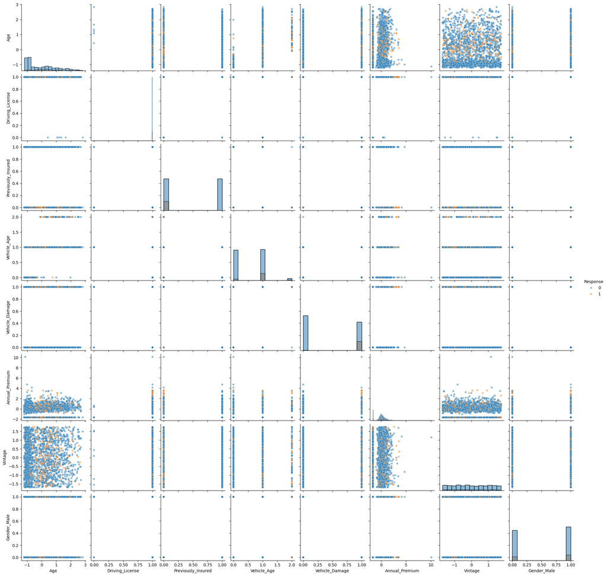

```python
# esclude il target e le variabili non idonee: id, Region_Code e Policy_Sales_Channel
pairplot_cols = [col for col in df_enc.columns if col not in ["Response", "id", "Region_Code", "Policy_Sales_Channel"]]

# Prende un campione casuale (2000 righe) del dataset per rendere il plot leggibile.
# Impostare random_state rende il risultato riproducibile (42 è un valore convenzionale).
df_sample = df_enc.sample(n=2000, random_state=42)

# Creare una copia di df_sample per la standardizzazione
df_sample_std = df_sample.copy()

# Standardizzare solo le variabili numeriche nel campione
scaler = StandardScaler()
df_sample_std[continuous_variables] = scaler.fit_transform(df_sample_std[continuous_variables])

sns.pairplot(df_sample_std, # datset
             vars=pairplot_cols, # variabili
             hue="Response", # colore dei punti in base a 'Response'
             diag_kind="hist", # istogramma sulla diagonale
             plot_kws={"alpha": 0.5, "s": 25})

plt.show()
```

#### **Interpretazione della Scatterplot matrix**

Attraverso l'analisi della scatterplot matrix, si evidenziano le seguenti features come maggiormente informative: 'Previously_Insured', 'Vehicle_Damage' e 'Vehicle_Age'.

La variabile **'Previously_Insured' è una feature fortemente informativa**, poichè si comporta allo stesso modo in tutti i grafici, cioè in relazione ad ogni altra variabile: quando 'Previously_Insured' è uguale a 1 (cioè quando l'utente ha già un veicolo assicurato), non si vede quasi nessun punto arancione, che corrisponde a 'Response' uguale a 1 (cioè a una risposta affermativa del cliente).

Questa osservazione è concorde con l'analisi del barplot di 'Previously_Insured' vs 'Response' che ha mostrato che le persone che sono già assicurate hanno una probabilità quasi nulla di accetare il cross-sell (0.1%), mentre la percentuale è molto maggiore per le persone che non hanno già una assicurazione (22.5%).

La variabile **'Vehicle_Damage' è una feature fortemente informativa**, in relazione alle altre variabili, mostra molti più punti arancioni ('Response' = 1) quando 'Vehicle_Damage' è uguale a 1, cioè quando l'utente ha danneggiato il veicolo in passato; mentre ci sono pochissimi punti arancioni in caso contrario. Il rapporto visivo tra colori non è assoluto, ma chiaramente sbilanciato.

L'osservazione è concorde con l'analisi del barplot di 'Vehicle_Damage' vs 'Response' che ha mostrato che chi ha avuto danni al veicolo in passato è molto più propenso ad assicurarsi (23.8% vs 0.5%).

La variabile **'Vehicle_Age' è una feature informativa**: in relazione alle altre variabili, mostra molti più punti arancioni ('Response' = 1) quando 'Vehicle_Age' è uguale a 2, cioè quando l'età del veicolo è maggiore di 2 anni, e diminuisce progressivamente con il diminuire dell'età del veicolo.

L'osservazione è concorde con l'analisi del barplot di 'Vehicle_Age' vs 'Response', che mostra che la propensione ad accettare il cross-sell aumenta con l'età del veicolo (< 1 anno: 4.4%, 1-2 anni: 17.4%, > 2 anni: 29.4%) in modo non lineare ma monotono.

# 2. Costruzione del Modello Predittivo

Per questo problema è stato scelto di costruire un modello di apprendimento supervisionato poichè l'output è noto, etichettato (colonna 'Response') ed è binario. Nello specifico, si utilizza un algoritmo di Regressione Logistica che restituisce la probabilità che una data osservazione appartenga alla classe positiva.

## 2.1. Split dei dati in training set e test set

```python
# Definizione delle feature
X = df_enc.drop(columns=["id", "Response"])

# Definizione del target
y = df_enc["Response"]

# Crazione degli array di training e di test, usando il 30% dei dati per il test set:

X_train, X_test, y_train, y_test = train_test_split(
    X, y,
    test_size=0.3, # 30% dei dati per il test
    stratify=y, # mantiene la stessa distribuzione di y in training set e test set
    random_state=42 # garantisce riproducibilità
)
```

## 2.2. Preprocessamento dei dati

- **Standardizzazione --> variabili quantitative continue**

"Age", "Annual_Premium" e "Vintage"

- **One-Hot Encoding --> variabili categoriche nominali**

"Policy_Sales_Channel" e "Region_Code"

Trasformazioni già fatte manualmente per preparare i dati per la scatterplot matrix, e che quindi non verranno ripetute:

- **Label encoding --> variabili categoriche binarie (sì/no)**

'Vehicle_Damage' (1: veicolo danneggiato sì, 0: veicolo danneggiato no), 'Response' (1:risposta positiva, 0:risposta negativa), 'Driving_License' (1: patente sì, 0:patente no), 'Previously_Insured' (1: veicolo assicurato sì, 0: veicolo assicurato no) e Gender_male (1: maschio sì, 0:maschio no).

- **Ordinal encoding --> variabili categoriche ordinali**

'Vehicle_Age' (0: <1 anno, 1: 1-2 anni, 2: >2 anni)

## 2.3. Creazione del modello di Regressione Logistica

Vengono di seguito utilizzati il modulo **Pipeline di sklearn.pipeline** e la classe **ColumnTransformer di sklearn.compose** che consentono di rendere il flusso di lavoro automatico, con step ordinati, codice piulito ed evitare il data leakage o altri errori.

**Pipeline** è un modulo fondamentale nella libreria scikit-learn, utilizzato per incapsulare e automatizzare una sequenza di passaggi di Machine Learning all'interno di un unico oggetto:

- preprocessing dei dati (normalizzazione, codifica, gestione valori mancanti)
- creazione del modello di classificazione o regressione

NOTA. Utilizzare Pipeline evita il data leakage e garantisce l'ordine corretto degli step.

Il **Data leakage** si verifica quando informazioni provenienti da fuori dal set di addestramento (training set) vengono inavvertitamente incluse nel processo di modellazione. Questo porta ad avere metriche di performance eccezionalmente alte durante la validazione, ma a scarse capacità di generalizzazione e predittive su dati reali.

Il data leakage si può verificare durante la fase di preprocessamento, se tutto il dataset viene utilizzato per calcolare informazioni che dovrebbero essere basate solo sul training set, quindi i dati del test set influenzano l'addestramento. Per questo motivo trasformazioni come la standardizzazione e il One-hot encoding devono essere fatte solo sul training test.

Label encoding e Ordinal encoding, invece, possono essere fatti prima dello split dei dati in trainig set e test set (quindi vengono applicati a tutti i dati) perchè: sono dei semplici mapping deterministici, non dipendono dal target, non imparano nulla dai dati e non si usano per calcolare statistiche.

**ColumnTransformer** è una classe di sklearn.compose (libreria scikit-learn) utilizzata per applicare trasformazioni differenti a specifiche colonne di un dataset, e poi concatenare tutto in un’unica matrice. ColumnTransformer è ottima per la gestione di dataset con dati misti: ad esempio colonne numeriche a cui applicare 'StandardScaler' e colonne categoriche a cui applicare 'OneHotEncoder'.

NOTA. Per gestire lo sbilanciamento delle classi della variabile target 'Response', vengono di seguito creati due modelli (A e B), in cui si utilizzano due tecniche diverse per la gestione di classi sbilanciate: Class Weights e Oversampling/Undersampling.

La gestione dello sbilanciamento è essenziale perchè quando una classe è molto più frequente dell'altra il modello tende a ignorare la classe minoritaria, facendo sempre previsioni che coincidono con la classe maggioritaria, ottenendo alta precisione generale ma pessimi risultati nel riconoscere esempi della classe minoritaria.

Il **Modello A** utilizza il parametro **class_weight="balanced"** che penalizza la classe più frequente nel modello: l'algoritmo regola i pesi in modo inversamente proporzionale alle frequenze delle classi nei dati di input, cioè assegna un peso maggiore alla classe minoritaria e un peso minore a quella maggioritaria.

Questo implica che durante l'addestramento, gli errori che il modello commette su un esempio di classe minoritaria avranno un peso maggiore, quindi verranno disincentivati maggiormente rispetto agli errori sugli esempio della classe maggioritaria.

Il **Modello B** utilizza una tecnica di resampling, cioè modifica il dataset di training per ottenere un equilibrio maggiore tra la classe minoritaria e la classe maggioritaria. In particolare, si può scegliere tra:

- Oversampling: aumentare il numero di esempi della classe minoritaria generando nuovi campioni sintetici.
- Undersampling: ridurre il numero di esempi della classe maggioritaria eliminandone alcuni.

In questo caso viene utilizzata una delle tecniche più utilizzate per l’oversampling: **SMOTE (Synthetic Minority Over-sampling Technique)**. SMOTE è un algoritmo che crea nuovi esempi sintetici della classe minoritaria anziché semplicemente replicare i dati esistenti. SMOTE i applica solo sui dati di training e prima del fitting del modello, in modo da evitare data leakage.

**NOTA. Per valutare i due modelli e scegliere il modello migliore, si confrontano AUC e metriche. Se queste risultano simili si sceglie di utilizzare come metodo di bilanciamento Class Weights, che è più adatto a dataset di grandi dimensioni.**

```python
# Raggruppamento delle variabili per il prepocessamento:

numeric_features = ["Age", "Annual_Premium", "Vintage"] # si applica standardizzazione
categorical_features = ["Policy_Sales_Channel", "Region_Code"]  # si applica one-hot encoding
binary_features = ["Driving_License", "Previously_Insured", "Vehicle_Damage", "Gender_Male"] # già 0/1 → passthrough
ordinal_features = ["Vehicle_Age"]  # già numerica → passthrough
```

```python
# Passaggi per preprocessamento con la classe 'ColumnTransformer'
preprocessor = ColumnTransformer(transformers=[
    ("num", StandardScaler(), numeric_features),  # applica .fit_transform() di StandardScaler al training-set
                                                  # e applica .transform() di StandardScaler al test-set
                                                  # in questo modo l'addestramento viene fatto solo sul training-set, evitando il data leakage
    ("cat", OneHotEncoder(drop='first', handle_unknown='ignore'), categorical_features),  # One-hot encoding solo sul train test
    ("bin", "passthrough", binary_features),
    ("ord", "passthrough", ordinal_features)
])


# MODELLO A - Class weights
# Passaggi preprocessamento + creazione del modello con il modulo 'Pipeline'
model_a = Pipeline(steps=[("preprocessor", preprocessor),
                          ("classifier", LogisticRegression(class_weight="balanced", # penalizza maggiormente gli errori sulla classe minoritaria
                                                            max_iter=1000,  # numero di iterazioni massime dell’algoritmo di ottimizzazione
                                                            random_state=42))  # riproducibilità dei risultati, 42 è un numero convenzionale
                         ])



# MODELLO B - SMOTE
smote_model = ImbPipeline(steps=[("preprocessor", preprocessor),
                             ("smote", SMOTE(random_state=42)), # SMOTE applicato SOLO sul training durante fit
                             ("classifier", LogisticRegression(max_iter=1000,
                                                               random_state=42))
                            ])
```

## 2.4. Stratified K-Fold Cross-Validation

Per la Stratified K-Fold Cross-Validation si divide il dataset in k sottoinsiemi (fold) di dimensioni simili, mantenendo la stessa distribuzione della variabile target in ogni fold. Questo aspetto è importante per problemi di classificazione con classi sbilanciate come questo.

Ad ogni iterazione, uno dei fold viene usato come test set e gli altri k-1 come training set. Si ripete k volte, così ogni fold viene usato una volta come test. Alla fine si calcola la media delle metriche di performance.

```python
# Definizione delle metriche:
scoring_metrics = ["roc_auc", "precision", "recall", "f1", "accuracy"]

# Definizione dei modelli
models = {"Modello A": model_a, "Modello B": smote_model}

# Configurazione del cross-validator:
cv = StratifiedKFold(n_splits=5, # divide i dati in 5 fold mantenendo la proporzione delle classi in ciascun fold
                     shuffle=True, # mescola i dati prima di dividerli, riducendo la possibilità di avere fold sbilanciati
                     random_state=42) # garantisce riproducibilità

# Ciclo per applicare Stratified K-Fold Cross-Validation ai due modelli:
cv_results = {}
for name, model in models.items():
    scores = cross_validate(model, X_train, y_train, cv=cv, scoring=scoring_metrics)
    cv_results[name] = scores

# Creazione di un dataframe riassuntivo
summary = []
for name, scores in cv_results.items():
    summary.append([
        name,
        scores['test_roc_auc'].mean(), scores['test_roc_auc'].std(),
        scores['test_precision'].mean(), scores['test_precision'].std(),
        scores['test_recall'].mean(), scores['test_recall'].std(),
        scores['test_f1'].mean(), scores['test_f1'].std(),
        scores['test_accuracy'].mean(), scores['test_accuracy'].std(),
    ])

df_cv_summary = pd.DataFrame(summary, columns=["Modello", "AUC_mean", "AUC_std",
                                               "Precision_mean", "Precision_std",
                                               "Recall_mean", "Recall_std",
                                               "F1_mean", "F1_std",
                                               "Accuracy_mean", "Accuracy_std"])


display(df_cv_summary)
```

|  | Modello | AUC_mean | AUC_std | Precision_mean | Precision_std | Recall_mean | Recall_std | F1_mean | F1_std | Accuracy_mean | Accuracy_std |
| --- | --- | --- | --- | --- | --- | --- | --- | --- | --- | --- | --- |
| 0 | Modello A | 0.848145 | 0.001955 | 0.275946 | 0.000714 | 0.936661 | 0.001494 | 0.426301 | 0.000981 | 0.69101 | 0.000869 |
| 1 | Modello B | 0.847452 | 0.001840 | 0.275366 | 0.000904 | 0.932868 | 0.001809 | 0.425215 | 0.001181 | 0.69089 | 0.001244 |

*WARNING --> Durante la Cross Validation può comparire il warning: "Found unknown categories during transform". Questo succede perché in alcuni fold di validazione possono comparire categorie che non erano presenti nel fold di training. Con handle_unknown="ignore" vengono codificate come zeri, quindi non è un problema per il modello.*

**Interpretazione dei risultati**

AUC, Precision, Recall, F1 e Accuracy sono praticamente uguali. Quindi i due modelli si comportano in modo molto simile. Nessuno dei due sembra significativamente migliore sull’insieme di metriche.

L’elevato valore di AUC (circa 0.85) indica una buona capacità discriminativa.

La soglia di classificazione standard (0.5) produce modelli con recall molto elevato (circa 93%) ma precision relativamente bassa (circa 27%). Questo suggerisce che i modelli sono adatti a individuare la maggior parte dei potenziali clienti interessati, ma al costo di numerosi falsi positivi.

Accuracy in questo caso non è una metrica informativa perchè il dataset è fortemente sbilanciato.

# 2.5. Fit finale sui dati completi

```python
# FIT FINALE SUI DATI COMPLETI

# MODELLO A
model_a.fit(X_train, y_train)

# MODELLO B
smote_model.fit(X_train, y_train)

# model.fit() comprende:
# 1. standardizzazione sul training set
# 2. One-hot encoding sul training set
# 3. transform sul training set
# 4. addestramento del modello di Rgerssione Logistica
```

```
Pipeline(steps=[('preprocessor',
                 ColumnTransformer(transformers=[('num', StandardScaler(),
                                                  ['Age', 'Annual_Premium',
                                                   'Vintage']),
                                                 ('cat',
                                                  OneHotEncoder(drop='first',
                                                                handle_unknown='ignore'),
                                                  ['Policy_Sales_Channel',
                                                   'Region_Code']),
                                                 ('bin', 'passthrough',
                                                  ['Driving_License',
                                                   'Previously_Insured',
                                                   'Vehicle_Damage',
                                                   'Gender_Male']),
                                                 ('ord', 'passthrough',
                                                  ['Vehicle_Age'])])),
                ('smote', SMOTE(random_state=42)),
                ('classifier',
                 LogisticRegression(max_iter=1000, random_state=42))])
```

# 2.6. Predizioni

```python
# MODELLO A
# PREDIZIONI TRAIN
y_pred_train = model_a.predict(X_train)
y_prob_train = model_a.predict_proba(X_train)[:, 1]
# PREDIZIONI TEST
y_pred_test = model_a.predict(X_test)  # predice la classe finale 0/1
y_prob_test = model_a.predict_proba(X_test)[:, 1]  # predice la probabilità della classe positiviva

# MODELLO B
# PREDIZIONI TRAIN
y_pred_train_smote = smote_model.predict(X_train)
y_prob_train_smote = smote_model.predict_proba(X_train)[:, 1]
# PREDIZIONI TEST
y_pred_test_smote = smote_model.predict(X_test)
y_prob_test_smote = smote_model.predict_proba(X_test)[:, 1]

# model.predict() comprende:
# 1. transform sul test set
# 2. predizione
```

*WARNING --> con 'Region_Code' e 'Policy_Sales_Channel' può succedere che nel test set ci siano categorie che non erano presenti nel training test. Questo può capitare perchè queste variabili hanno molte categorie, alcune delle quali sono molto rare, e con lo split train/test, alcune finiscono solo nel test. Il modello funziona comunque correttamente.*

# 3. Valutazione e scelta del modello

Per valutare i due modelli e scegliere il migliore, si confrontano AUC e metriche.

## 3.1. Curva ROC (= Receiver Operating Characteristic) e AUC (= Area Under the ROC Curve)

La **curva ROC (= Receiver Operating Characteristic)** permette di verificare la capacità di un modello di classificazione binaria, di discriminare tra le due classi positive e negative, per diversi valori di threshold, e quindi di individuare il valore di threshold ottimale.

- Sull’asse x c’è il False Positive Rate (FPR), cioè la proporzione di negativi erroneamente classificati come positivi (falsi positivi / totali negativi).

Sull’asse y c’è il True Positive Rate (TPR), cioè la sensibilità o recall, la proporzione di veri positivi correttamente identificati (veri positivi / totali positivi).

Il **valore di threshold** è il valore soglia che si utilizza per determinare se una probabilità è da associare a una classificazione positiva o negativa. Di defaul il threshold è mlpostato a 0.5, ma si può scegliere un valore differente se si vogliono penalizzare maggiormente i falsi positivi (si aumenta la soglia) o i falsi negativi (si diminuisce la soglia) Il threshold ottimale permette bilanciare True Positive Rate e False Positive Rate.i

L’**AU (= Area Under the ROC Curve)C**sintetizza la qualità generale del modello, cioè permette capire quanto bene il modello distingue le classi. Valori di AUC vicini a 1 indicano un modello ottimo.

Vengono confrontate le AUC di entrambi i modelli.

```python
# Funzione che mostra la ROC Curve e calcola AUC e Threshold ottimale

def plot_roc(y_true, y_prob, model_name="Modello"):
    """
    Calcola e plota la ROC curve, AUC e soglia ottimale (Youden's J) per un modello.

    Args:
        y_true: array-like, target vero
        y_prob: array-like, probabilità previste dal modello
        model_name: str, nome del modello per il plot

    Returns:
        optimal_threshold: soglia ottimale calcolata
        roc_auc: AUC del modello
    """

    # Calcolo FPR, TPR e soglie
    fpr, tpr, thresholds = roc_curve(y_true, y_prob)

    # Calcolo AUC
    roc_auc = auc(fpr, tpr)

    # Calcola la soglia ottimale (Youden's J statistic)
    J = tpr - fpr
    ix = np.argmax(J)
    optimal_threshold = thresholds[ix]

    # Stampa valori
    print(f"{model_name} - AUC: {roc_auc:.4f}")
    print(f"{model_name} - Optimal Threshold: {optimal_threshold:.4f}")

    # Plot della curva ROC
    plt.figure(figsize=(8,6))
    plt.plot(fpr, tpr, color='blue', lw=2, label=f'ROC curve (AUC = {roc_auc:.4f})')
    plt.plot([0, 1], [0, 1], color='gray', linestyle='--', label='Random guess')

    # evidenzia il punto in corrispondenza della soglia ottimale
    plt.scatter(fpr[ix], tpr[ix], marker='o', color='red',
                label=f'Optimal threshold = {optimal_threshold:.2f}')

    plt.xlabel('False Positive Rate')
    plt.ylabel('True Positive Rate (Recall)')
    plt.title(f'ROC Curve - {model_name}')
    plt.legend(loc='lower right')
    plt.grid()
    plt.show()

    return optimal_threshold, roc_auc
```

```
Modello A - AUC: 0.8505
Modello A - Optimal Threshold: 0.5101
```

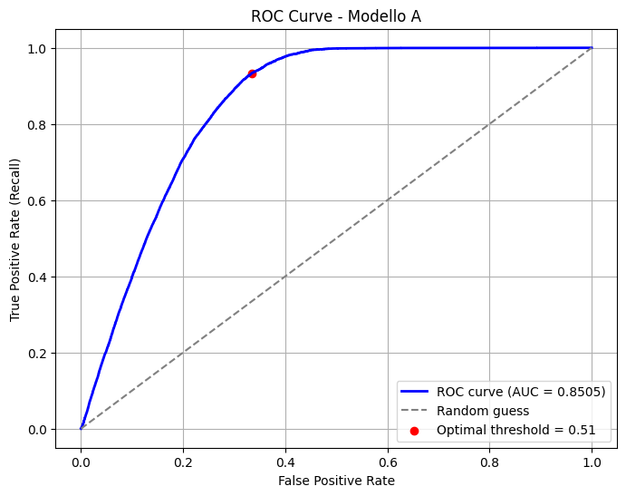

```
Modello B - AUC: 0.8501
Modello B - Optimal Threshold: 0.5176
```

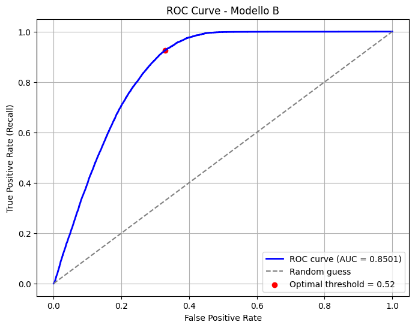

```python
# Modello A
optimal_threshold_a, roc_auc_a = plot_roc(y_test, y_prob_test, model_name="Modello A")

# Modello B (SMOTE)
optimal_threshold_b, roc_auc_b = plot_roc(y_test, y_prob_test_smote, model_name="Modello B")
```

### Interprtetazione dei risultati

Per entrambi i modelli si ottiene una AUC (= Area Under the Curve) di 0.85 circa: un valore molto buono, che indica buona capacità discriminativa, tipica di un modello solido: il modello riesce a distinguere efficacemente tra clienti interessati e non interessati all’assicurazione veicolo.

La soglia ottimale calcolata tramite la statistica di Youden risulta molto vicina a 0.5 per entrambi i modelli. Questo suggerisce che il compromesso tra True Positive Rate e False Positive Rate è già ben bilanciato con la soglia standard, e che le tecniche di gestione dello sbilanciamento (class weights e SMOTE) hanno funzionato correttamente.

Inoltre, l’assenza di differenze significative tra i due modelli indica che la regressione logistica con pesi bilanciati è sufficiente per affrontare il problema, senza necessità di ricorrere a tecniche di oversampling. Di seguito verranno confrontate anche metriche Precision, Recall e F1-score per la scelta del modello.

**NOTA**. Poiché il dataset è fortemente sbilanciato, la scelta della soglia decisionale dovrebbe idealmente essere guidata da considerazioni di business (costo dei falsi positivi vs perdita di opportunità commerciali) piuttosto che esclusivamente da criteri statistici. Al momento non siamo a conoscenza del costo del profitto medio per una polizza auto nè del costo del contatto di un cliente, quindi non approfondiremo questa analisi dei profitti.

**Interpretazione dei risultati**

## 3.2. Predizioni con threshold ottimale

```python
# MODELLO A
# Training set
y_pred_train_opt = (y_prob_train >= optimal_threshold_a).astype(int)
# Test set
y_pred_test_opt = (y_prob_test >= optimal_threshold_a).astype(int)

# MODELLO B
# Training set
y_pred_train_smote_opt = (y_prob_train_smote >= optimal_threshold_b).astype(int)
# Test set
y_pred_test_smote_opt = (y_prob_test_smote >= optimal_threshold_b).astype(int)
```

## 3.3. Confronto delle metriche

Vengono valuate le metriche dei due modelli e confrontate tra loro.

```python
# Funzione per stampare metriche principali per entrambi i modelli

def compare_models_metrics(y_true, y_pred_a, y_pred_b, model_names=["Modello A", "Modello B"]):

    metrics = []
    for name, y_pred in zip(model_names, [y_pred_a, y_pred_b]):
        precision = precision_score(y_true, y_pred)
        recall = recall_score(y_true, y_pred)
        f1 = f1_score(y_true, y_pred)
        accuracy = accuracy_score(y_true, y_pred)
        metrics.append([name, precision, recall, f1, accuracy])

    df_metrics = pd.DataFrame(metrics, columns=["Modello", "Precision", "Recall", "F1-score", "Accuracy"])
    return df_metrics

# Confronto sul training set
df_comparison_train = compare_models_metrics(y_train, y_pred_train_opt, y_pred_train_smote_opt)
print("Confronto modelli - Training Set")
display(df_comparison_train)

# Confronto sul test set
df_comparison_test = compare_models_metrics(y_test, y_pred_test_opt, y_pred_test_smote_opt)
print("Confronto modelli - Test Set")
display(df_comparison_test)
```

```
Confronto modelli - Training Set
```

|  | Modello | Precision | Recall | F1-score | Accuracy |
| --- | --- | --- | --- | --- | --- |
| 0 | Modello A | 0.279338 | 0.932349 | 0.429881 | 0.696899 |
| 1 | Modello B | 0.281077 | 0.925222 | 0.431167 | 0.700790 |

```
Confronto modelli - Test Set
```

|  | Modello | Precision | Recall | F1-score | Accuracy |
| --- | --- | --- | --- | --- | --- |
| 0 | Modello A | 0.280339 | 0.933562 | 0.431194 | 0.698127 |
| 1 | Modello B | 0.282168 | 0.926425 | 0.432582 | 0.702124 |

**Interpretazione dei risultati** Le differenze tra i due modelli sono minime, praticamente trascurabili. Quindi si sceglie il modello A con Class Weights, che è la tecnica di bilanciamento più adatta a dataset grandi, come questo.

**--> Di seguito si continua con la valutazione e il commento del modello scelto.**

# 3.4. Valutazione del modello scelto

## Matrice di Confusione

La matrice di confusione è una tabella 2x2 che riassume le performance di un modello di classificazione binaria, evidenziando quanti e quali errori ha commesso.

Sull’asse delle y sono mostrate le classi reali, cioè le classi associate all’osservazione all’interno del dataset; sull’asse delle x sono mostrate le classi predette con il modello.

- TP (True Positive) = Osservazioni positive classificate come positive
- FP (False Positive) = Osservazioni negative classificate come positive
- FN (False Negative) = Osservazioni positive classificate come negative
- TN (True Negative) = Osservazioni negative classificate come negative

```python
# MATRICE DI CONFUSIONE

def plot_confusion_matrix(y_true, y_pred, labels=["Non Interessato", "Interessato"]):

    # Calcola la matrice di confusione
    cm = confusion_matrix(y_true, y_pred, normalize='all')

    # Matrice di confusione con le percentuali
    cm_percent = cm * 100

    # Annotazioni con il simbolo %
    annot = np.array([["{:.2f}%".format(value) for value in row] for row in cm_percent])

    # Trasformiamo in DataFrame per usarlo con seaborn
    df_cm = pd.DataFrame(cm, index=labels, columns=labels)

    plt.figure(figsize=(6,5))
    sns.heatmap(df_cm, annot=annot, fmt="")
    plt.ylabel("Classe Reale")
    plt.xlabel("Classe Predetta")
    plt.title("Confusion Matrix")
    plt.show()


    # Precision e Recall per classe
    for i, label in enumerate(labels):
        precision = precision_score(y_true, y_pred, pos_label=i)
        recall = recall_score(y_true, y_pred, pos_label=i)
        print(f"Classe '{label}': Precision = {precision:.4f}, Recall = {recall:.4f}")
```

```
MATRICE DI CONFUSIONE - TRAINING SET
```

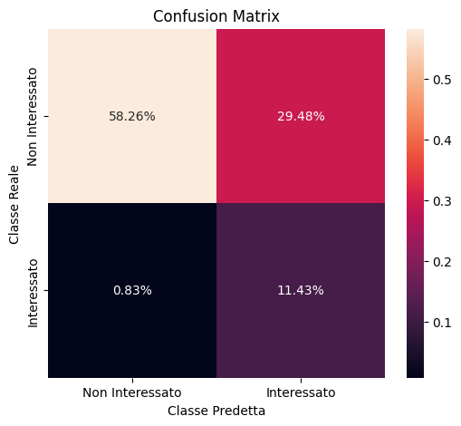

```
Classe 'Non Interessato': Precision = 0.9860, Recall = 0.6640
Classe 'Interessato': Precision = 0.2793, Recall = 0.9323
--------------------------------------------------------------------------------------------------
MATRICE DI CONFUSIONE - TEST SET
```

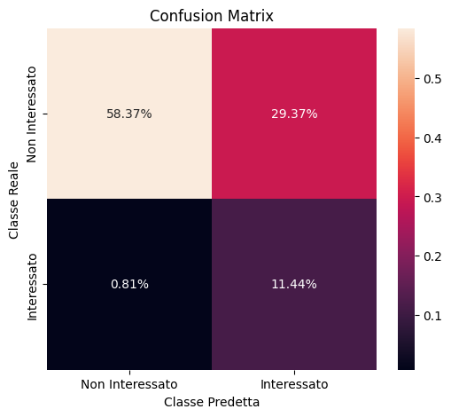

```
Classe 'Non Interessato': Precision = 0.9862, Recall = 0.6652
Classe 'Interessato': Precision = 0.2803, Recall = 0.9336
```

```python
print("MATRICE DI CONFUSIONE - TRAINING SET")
plot_confusion_matrix(y_train, y_pred_train_opt)
print("--------------------------------------------------------------------------------------------------")
print("MATRICE DI CONFUSIONE - TEST SET")
plot_confusion_matrix(y_test, y_pred_test_opt)
```

## Metriche

```python
print("METRICHE - TRAIN REPORT")
print(classification_report(y_train, y_pred_train_opt))
print("METRICHE - TEST REPORT")
print(classification_report(y_test, y_pred_test_opt))
```

```
METRICHE - TRAIN REPORT
              precision    recall  f1-score   support

           0       0.99      0.66      0.79    234079
           1       0.28      0.93      0.43     32697

    accuracy                           0.70    266776
   macro avg       0.63      0.80      0.61    266776
weighted avg       0.90      0.70      0.75    266776

METRICHE - TEST REPORT
              precision    recall  f1-score   support

           0       0.99      0.67      0.79    100320
           1       0.28      0.93      0.43     14013

    accuracy                           0.70    114333
   macro avg       0.63      0.80      0.61    114333
weighted avg       0.90      0.70      0.75    114333
```

## 3.5. Interpretazione dei risultati - Matrici di confusione e metriche

Le matrici di confusione sono state calcolate sia sul training set sia sul test set utilizzando la soglia ottimizzata.

I valori di Precision, Recall, F1 Score e Accuracy per training set e per il test set sono pressochè identici: questo indica che il modello presenta una **buona generalizzazione** e **non si verifica overfitting**.

**Classe 1: clienti che accettano il cross-sell**. La classe mostra:

- Precision bassa (28%) --> indica che tra tutti i clienti che il modello identifica come compratori, solo il 28% accetteà davvero, cioè il 72% sono **falsi positivi**.
- Recall molto alto (93%) --> indica che il modello **intercetta quasi tutti i clienti potenzialmente interessati** ad accettare il cross-sell, quindi è molto sensibile. Questo è ottimo se l’obiettivo è non perdere clienti potenzialmente interessati.
- F1 è moderato (43%) perchè è influenzato sia da Precision che da recall, e in questo caso Precision è molto bassa.

**Classe 0: clienti che rifiutano il cross-sell**. la classe mostra:

- Precision molto alta (99%) --> indica che quando il modello predice che un cliente non è interessato, la previsione è quasi sempre corretta. Questo indica un’elevata affidabilità nel classificare i veri non interessati.
- Recall (66%) --> indica che il modello identifica correttamente circa due terzi dei clienti non interessati, mentre il restante terzo viene classificato come potenzialmente interessato (falsi positivi).

Questo comportamento è coerente con la strategia adottata: il modello accetta un certo numero di falsi positivi pur di mantenere molto elevata la capacità di intercettare la classe positiva.

Accuracy sembra discreta (70%), ma dato che il datset è fortemente sbilanciato riguardo la distribuzione di 'Response', questa non è una metrica indicativa del modello.

## Interpretazione di Business

A questo punto è il cliente AssurePredict che deve valutare se è più dispendioso:

- contattare clienti che non accettano il cross-sell: costo del call center, costo del marketing ...
- perdere un cliente che avrebbe accettato il cross-sell: mancato guadagno

Il cliente deve indicare se preferisce:

- una startegia più aggressiva (con soglia circa 0.5) che intercetta quasi tutti i clienti interessati, ma che presenta un gran numero di falsi positivi.
- oppure una strategia più selettiva (con soglia più alta) con un modello più equilibrato, che perde qualche cliente potenzialmente interessato al cross-sell, ma riduce di molto i falsi positivi.

Non essendo disponibili dati riguardanti i costi per l'azienda di contattare clienti non interessati e di perdere una vendita non possiamo stabilire quale sia la soglia da preferire. Si suppone che sia meglio evitare il mancato guadagno, quindi una soglia più vicina a 0.5.

## Interpretazione complessiva

Il modello mostra un comportamento coerente con una strategia di cross-selling orientata alla massimizzazione del profitto:

- intercetta quasi tutti i clienti potenzialmente interessati (recall elevato);
- accetta un numero consistente di falsi positivi (precision contenuta);
- mantiene performance stabili tra training e test, dimostrando buona generalizzazione.

Il modello non è ottimizzato per “essere accurato”, ma per supportare decisioni economicamente vantaggiose, privilegiando la riduzione delle opportunità perse rispetto alla minimizzazione dei contatti non produttivi.